# Monte Carlo simulation exercise

Nikola Sekulovski

2021-09-23

```r
library(tidyverse)
```

# The Confidence Interval

In this exercise I will try to repeat the example given by [Gerko Vink](https://www.gerkovink.com/markup/Wk1/Solution_to_Ex1.html)

The main idea of this exercise is to illustrate the nature of the *Confidence Interval* as described by [Neyman (1934)](http://www.stat.cmu.edu/~brian/905-2008/papers/neyman-1934-jrss.pdf)

We set a seed to make our results reproducible:

```r
set.seed(6465)
```

- The first step is to take 100 samples (in this case of size 800) from a *normal distributuon* with $\mu = 0$ and $\sigma = 1$:

```r
samples <-plyr::rlply(100, rnorm(800, 0, 1))
```

- Secondly, we need to calculate for the mean of each sample: the absolute bias; standard error lower bound of the 95% confidence interval and upper bound of the 95% confidence interval.

We can construct a function that does this:

```r
samp_function <- function(x) {

  m <- mean(x)
  n <- length(x)
  se <- 1/sqrt(n)
  bias <- abs(-0 - m)
  df <- n - 1
  interval <- qt(.975, df) * se
  return(c(m, bias, se, m - interval, m + interval))

}

format <- c("Mean" = 0, "Bias" = 0, "Std.Err" = 0, "Lower" = 0, "Upper" = 0)
```

Now we use the constructed function `samp_function` on all 100 samples contained in the object `samples`. And we also add a new column to the results that indicates which CI of the respective samples does contain $\mu$.

```r
results <- samples %>%
  vapply(., samp_function, format) %>%
  t %>%
  as_tibble %>%
  mutate(Covered = ifelse(Lower < 0 & Upper > 0, 1, 0))
```

We can also add a table with the sample statistics of the samples whose CI’s do not contain $\mu$.

```r
results %>%
  filter(Covered ==0) %>%
  kableExtra::kable()
```

| Mean | Bias | Std.Err | Lower | Upper | Covered |
| --- | --- | --- | --- | --- | --- |
| -0.0945589 | 0.0945589 | 0.0353553 | -0.1639592 | -0.0251585 | 0 |
| 0.0740058 | 0.0740058 | 0.0353553 | 0.0046055 | 0.1434062 | 0 |

And finally we can also make a nice plot illustrating everything that we did so far.

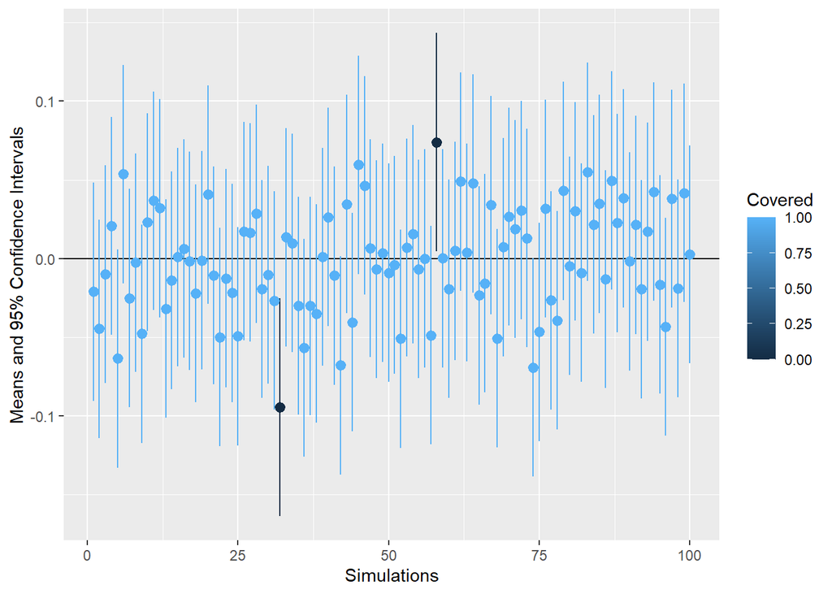

```r
lims <- aes(ymax = results$Upper, ymin = results$Lower)
ggplot(results, aes(y=Mean, x=1:100, colour = Covered)) +
  geom_hline(aes(yintercept = 0)) +
  geom_pointrange(lims) +
  xlab("Simulations") +
  ylab("Means and 95% Confidence Intervals")
```

In this case only two out of 100 CI’s do not include the true population mean.

# The Central Limit Theorem

Here we will also try to illustrate the [Central Limit Theorem](https://en.wikipedia.org/wiki/Central_limit_theorem), in it’s most basic form, with a very simple example.

First we draw 1000 samples (again of size 800), form , say, a *Poisson* distribution, of course we could’ve drawn them from a uniform or an exponential as well.

```r
samples_2 <- samples <-plyr::rlply(1000, rpois(800, 2))
```

Now we calculate the mean for each sample:

```r
means <- samples_2 %>%
  lapply(., mean) %>%
  as.data.frame() %>%
  t()
```

And now we plot a histogram of the resulting means:

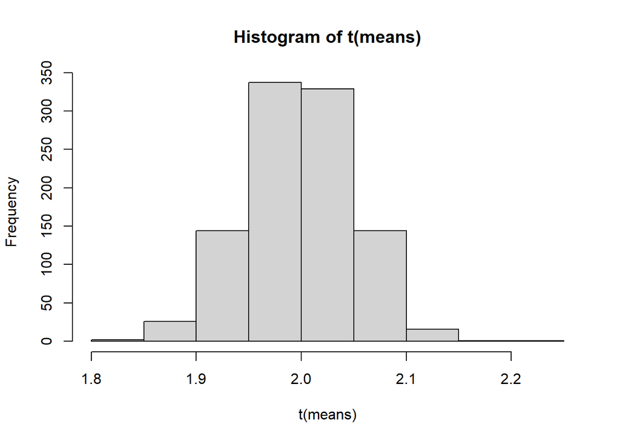

```r
hist(t(means))
```